# Discussion Section Worksheet #5

Anupama Bhatta

October 10, 2023

# Learning objectives

- Practice using linear models
- Interpret linear model coefficients

# What makes Pokemon powerful?

The data set for this Problem Set (from https://www.kaggle.com/abcsds/pokemon) includes 800 Pokemon, including their number, name, first and second type, and basic stats: HP, Attack, Defense, Special Attack, Special Defense, and Speed.

This are the raw attributes that are used for calculating how much damage an attack will do in the games. This dataset is about the pokemon games (NOT pokemon cards or Pokemon Go).

The data as described by Myles O'Neill is:

- id_number: ID for each pokemon
- name: Name of each pokemon
- type1: Each pokemon has a type, this determines weakness/resistance to attacks
- type2: Some pokemon are dual type and have 2
- total: sum of all stats that come after this, a general guide to how strong a pokemon is
- hp: hit points, or health, defines how much damage a pokemon can withstand before fainting
- attack: the base modifier for normal attacks (eg. Scratch, Punch)
- defense: the base damage resistance against normal attacks
- sp_attack: special attack, the base modifier for special attacks (e.g. fire blast, bubble beam)
- sp_defense: the base damage resistance against special attacks
- speed: determines which pokemon attacks first each round

The data for this table has been acquired from several different sites, including pokemon.com, pokemondb and bulbapedia

## Read in some libraries you will need

## Load in the data

```r
pokemon <- read_csv('https://raw.githubusercontent.com/umsi-data-science/data/main/pokemon.csv')
```

## Inspect the data

Use your preferred way of visually inspecting the data to get a sense for what it looks like.

```r
glimpse(pokemon)
```

```
## Rows: 800
## Columns: 13
## $ id_number  <dbl> 1, 2, 3, 3, 4, 5, 6, 6, 6, 7, 8, 9, 9, 10, 11, 12, 13, 14, …
## $ name       <chr> "Bulbasaur", "Ivysaur", "Venusaur", "VenusaurMega Venusaur"…
## $ type1      <chr> "Grass", "Grass", "Grass", "Grass", "Fire", "Fire", "Fire",…
## $ type2      <chr> "Poison", "Poison", "Poison", "Poison", NA, NA, "Flying", "…
## $ total      <dbl> 318, 405, 525, 625, 309, 405, 534, 634, 634, 314, 405, 530,…
## $ hp         <dbl> 45, 60, 80, 80, 39, 58, 78, 78, 78, 44, 59, 79, 79, 45, 50,…
## $ attack     <dbl> 49, 62, 82, 100, 52, 64, 84, 130, 104, 48, 63, 83, 103, 30,…
## $ defense    <dbl> 49, 63, 83, 123, 43, 58, 78, 111, 78, 65, 80, 100, 120, 35,…
## $ sp_attack  <dbl> 65, 80, 100, 122, 60, 80, 109, 130, 159, 50, 65, 85, 135, 2…
## $ sp_defense <dbl> 65, 80, 100, 120, 50, 65, 85, 85, 115, 64, 80, 105, 115, 20…
## $ speed      <dbl> 45, 60, 80, 80, 65, 80, 100, 100, 100, 43, 58, 78, 78, 45, …
## $ generation <dbl> 1, 1, 1, 1, 1, 1, 1, 1, 1, 1, 1, 1, 1, 1, 1, 1, 1, 1, 1, 1,…
## $ legendary  <lgl> FALSE, FALSE, FALSE, FALSE, FALSE, FALSE, FALSE, FALSE, FAL…
```

## Exploring the relationship between attack and defense

## Plot it

Create a scatterplot showing the relationship between attack (on the y-axis) and defense (on the x-axis). Show the line of best fit on this graph, too.

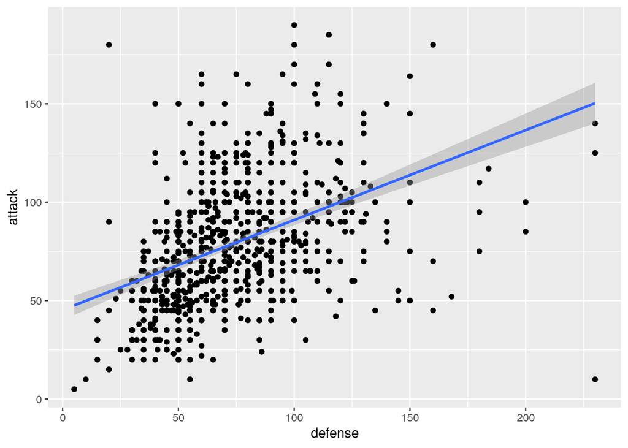

```r
ggplot(data = pokemon, mapping = aes(x = defense, y = attack))+
  geom_point()+
  geom_smooth(method = lm, se = TRUE)
```

## What's the correlation between attack and defense?

Find the correlation coefficient, r, for the correlation between attack and defense. Then, in plain language, tell us what this value says about the direction and strength of the relationship.

```r
cor(pokemon$defense, pokemon$attack)
```

```
## [1] 0.4386871
```

There is a slight positive correlation coefficient value between attack and defense, which lets us know that if the attack value increases, defense also increases, and if attack value decreases, defense also decreases. This realtionship signifies a positive correlation.

## Fit a regression model of attack as a function of defense.

You'll want to use some tools from our regression lecture- that's Chapter 5 in Modern Dive.

```r
reg_model <- lm(attack ~ defense, data = pokemon)
```

## Interpret the model

First, find a way to print out a summary of the regression model in a useful format.

```r
get_regression_table(reg_model)
```

```
## # A tibble: 2 × 7
##   term      estimate std_error statistic p_value lower_ci upper_ci
##   <chr>        <dbl>     <dbl>     <dbl>   <dbl>    <dbl>    <dbl>
## 1 intercept   45.3       2.65       17.1       0   40.1     50.5
## 2 defense      0.457     0.033      13.8       0    0.392    0.522
```

Now, write an equation that summarizes what it means. Your answer should be of the form `attack = SOME_NUMBER + SOME_OTHER_NUMBER * defense`.

attack = 45.284 + 0.457 * defense

## Make a prediction with new data

Given what you've written above, what would be the attack for a Pokemon whose defense is 21?

```r
#attack = 45.284 + 0.457 * defense
attack = 45.284 + 0.457 * 21
attack = 54.881
```

## Can we model attack by type?

What if we had used `type` instead of `defense` to model `attack`? Fit a new linear model of `attack` as a function of `type`, print out a summary table, and then explain what each row of the table represents.

```r
reg_model2 <- lm(attack ~ type1, data = pokemon)
  get_regression_table(reg_model2)
```

```
## # A tibble: 18 × 7
##    term            estimate std_error statistic p_value lower_ci upper_ci
##    <chr>              <dbl>     <dbl>     <dbl>   <dbl>    <dbl>    <dbl>
##  1 intercept         71.0        3.71    19.1     0        63.7     78.3
##  2 type1: Dark       17.4        6.67     2.61    0.009     4.33    30.5
##  3 type1: Dragon     41.2        6.60     6.24    0        28.2     54.1
##  4 type1: Electric   -1.88       5.95    -0.316   0.752   -13.6      9.80
##  5 type1: Fairy      -9.44       8.35    -1.13    0.258   -25.8      6.95
##  6 type1: Fighting   25.8        7        3.69    0        12.1     39.5
##  7 type1: Fire       13.8        5.66     2.44    0.015     2.68    24.9
##  8 type1: Flying      7.78      15.9      0.491   0.624   -23.4     38.9
##  9 type1: Ghost       2.81       6.60     0.426   0.67    -10.1     15.8
## 10 type1: Grass       2.24       5.23     0.429   0.668    -8.03    12.5
## 11 type1: Ground     24.8        6.60     3.76    0        11.8     37.7
## 12 type1: Ice         1.78       7.31     0.243   0.808   -12.6     16.1
## 13 type1: Normal      2.50       4.85     0.516   0.606    -7.01    12.0
## 14 type1: Poison      3.71       6.91     0.537   0.592    -9.86    17.3
## 15 type1: Psychic     0.485      5.52     0.088   0.93    -10.3     11.3
## 16 type1: Rock       21.9        5.95     3.68    0        10.2     33.6
## 17 type1: Steel      21.7        7        3.10    0.002     7.99    35.5
## 18 type1: Water       3.18       4.72     0.674   0.501    -6.08    12.4
```

Intercept: This row represents the intercept or the constant term in the linear regression model. In this case, the estimated intercept is approximately 70.971.

type1: Dark: This row represents the coefficient associated with the categorical variable "type1" when it is equal to "Dark." It shows how the "attack" variable changes when the Pokémon type is "Dark." The estimated coefficient for this category is approximately 17.416.

type1: Dragon: Similar to the previous row, this one represents the coefficient for the "Dragon" type. It indicates how the "attack" variable changes when the Pokémon type is "Dragon." The estimated coefficient for this category is approximately 41.154.

## Make a prediction

Say we have a Pokemon that is Ghost type. Using the model you just fit, what would be its estimated attack?

```r
#attack = intercept + Ghost * 2.810
attack = 70.971 + 1 * 2.810
attack = 73.781
```

## Which pokemon were not well-described by the model?

Every model tries to capture relationships present in many Pokemon, but not all Pokemon will be well described by the line of best fit. Which Pokemon is the WORST fit by our model of attack as a function of type? Hint- you'll want to look at the residuals.

```r
worst_fit <- get_regression_points(reg_model2, ID = 'name')
worst_fit %>% mutate(absolute_val = abs(residual)) %>%
arrange(desc(absolute_val))
```

```
## # A tibble: 800 × 6
##    name                    attack type1   attack_hat residual absolute_val
##    <chr>                    <dbl> <chr>        <dbl>    <dbl>        <dbl>
##  1 MewtwoMega Mewtwo X        190 Psychic       71.5    119.         119.
##  2 HeracrossMega Heracross    185 Bug           71.0    114.         114.
##  3 DeoxysAttack Forme         180 Psychic       71.5    109.         109.
##  4 GalladeMega Gallade        165 Psychic       71.5     93.5         93.5
##  5 BanetteMega Banette        165 Ghost         73.8     91.2         91.2
##  6 HoopaHoopa Unbound         160 Psychic       71.5     88.5         88.5
##  7 Slaking                    160 Normal        73.5     86.5         86.5
##  8 Regigigas                  160 Normal        73.5     86.5         86.5
##  9 GroudonPrimal Groudon      180 Ground        95.8     84.2         84.2
## 10 PinsirMega Pinsir          155 Bug           71.0     84.0         84.0
## # … with 790 more rows
## # ℹ Use `print(n = ...)` to see more rows
```

Therefore, we can see that the Pokemon with the worst fit by our model of attack as a function of type is MewtwoMega Mewtwo X.